# Homework 2/ Editing theme and scale of plots with ggplot2

Tesfahun Tegene Boshe

04/11/2021

## Instructions

- Find interesting dataset and prepare short report (in R Markdown) which will consist:
- short description of the dataset,
- 3 scatterplots which will present interesting relationships between variables,
- brief comments which describes obtained results.
- Then, edit theme of the graphs and all scales of the graph and prepare publication-ready plots.

## Necessary packages

```r
requiredPackages = c("ggplot2","dplyr","tidyr","carData")

for(i in requiredPackages){if(!require(i,character.only = TRUE)) install.packages(i)}
for(i in requiredPackages){if(!require(i,character.only = TRUE)) library(i,character.only = TRUE)}
```

## Dataset

For this task, Salaries dataset, containing the salary, sex and other attributes for Assistant Professors, Associate Professors and Professors in a college in the U.S will be used.

The dataset is available with *carData* package. The variables are as follows:

*Variable* | *Description*

- rank | a factor with levels AssocProf AsstProf Prof
- discipline | a factor with levels A (“theoretical” departments) or B (“applied” departments).
- yrs.since.phd | years since PhD.
- yrs.service | years of service.
- sex | a factor with levels Female Male
- salary | nine-month salary, in dollars.

```r
head(Salaries) # the first 6 observations
```

```
##        rank discipline yrs.since.phd yrs.service  sex salary
## 1      Prof          B            19          18 Male 139750
## 2      Prof          B            20          16 Male 173200
## 3  AsstProf          B             4           3 Male  79750
## 4      Prof          B            45          39 Male 115000
## 5      Prof          B            40          41 Male 141500
## 6 AssocProf          B             6           6 Male  97000
```

## plots

### Plot 1. Salary vs years of service for each sex

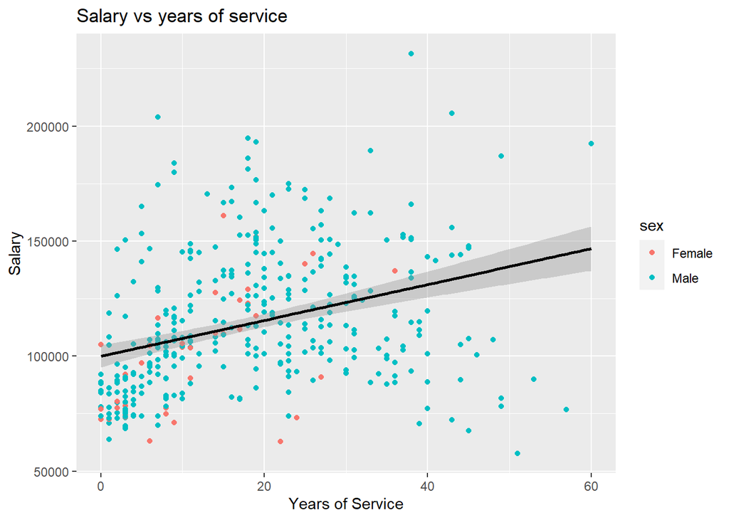

```r
p1 <- ggplot(data=Salaries, aes(x=yrs.service,y = salary, color=sex))+
      geom_point() +
      labs(x = "Years of Service", y = "Salary")+
      ggtitle("Salary vs years of service") +
      geom_smooth(method = "lm", color = "black")

p1
```

comments:

- majority of the female professors are paid less than the market average
- there is a positive correlation between years of service and salary variables.
- this is with the exception to the age group 40-60 years of service, where there is a general decrease in salary
- with years of experience

### Plot 2.1 Salary vs years since PHD for each rank

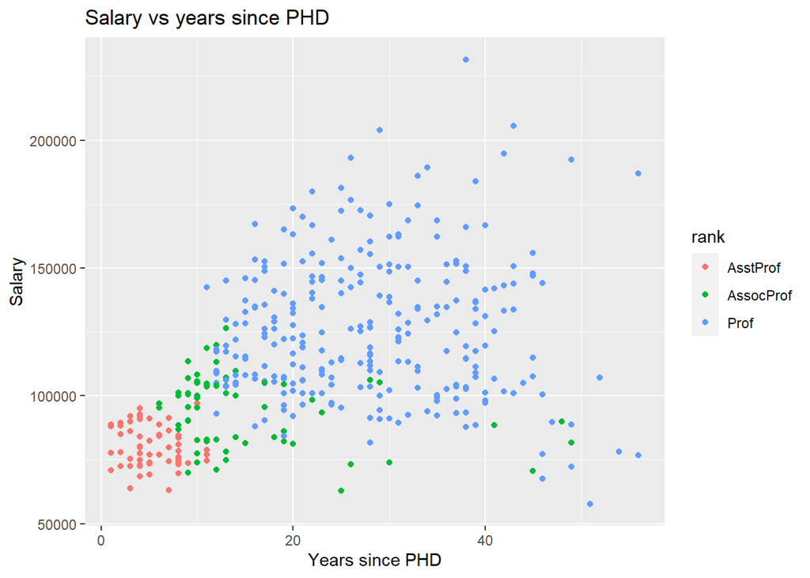

```r
p2_1 <- ggplot(data=Salaries, aes(x=yrs.since.phd,y = salary, color=rank))+
      geom_point() +
      labs(x = "Years since PHD", y = "Salary")+
      ggtitle("Salary vs years since PHD")

p2_1
```

Comments

### Plot 2.2 Salary vs years since PHD for each discipline

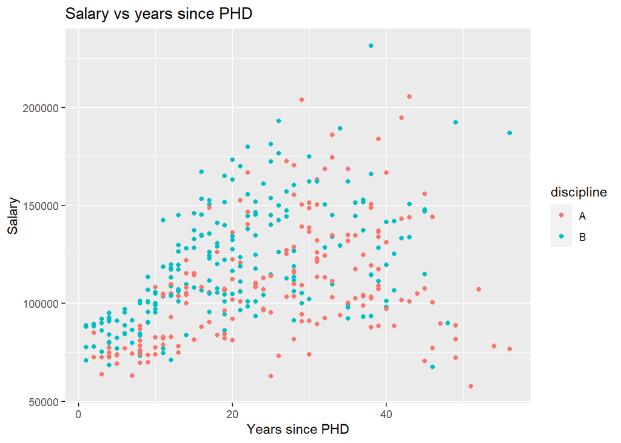

```r
p2_2 <- ggplot(data=Salaries, aes(x=yrs.since.phd,y = salary, color=discipline))+
      geom_point() +
      labs(x = "Years since PHD",  y = "Salary")+
      ggtitle("Salary vs years since PHD")

p2_2
```

Comments:

- applied departments pay more than theoretical departments

### plot 2.3 Salary vs years since PHD for each rank X discipline

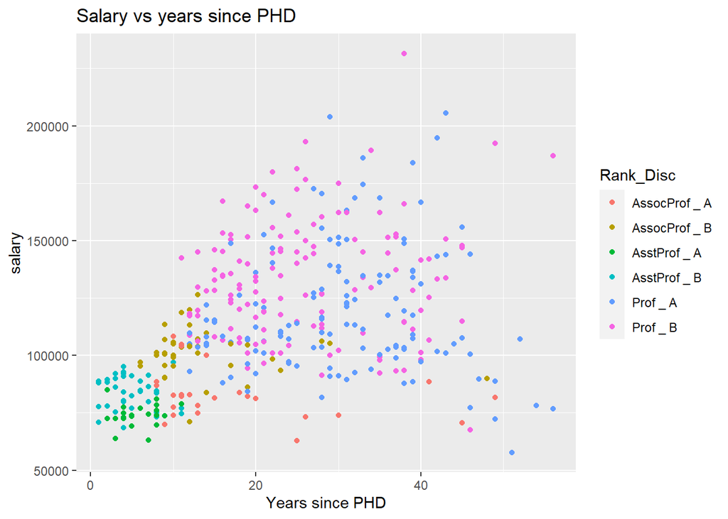

```r
Salaries$Rank_Disc <- paste(Salaries$rank,"_", Salaries$discipline)
# a new variable Rank_Disc is a cross product of rank and discipline

p2_3<-ggplot(data=Salaries, aes(x=yrs.since.phd,y = salary, color=Rank_Disc))+
      geom_point() +
      labs(x = "Years since PHD")+
      ggtitle("Salary vs years since PHD")

p2_3
```

Comments:

- Professors in applied departments are of the highest market value
- The properties in 2.1 and 2.2 are observed here too.

### Plot 3. Bar plot of counts of individuals per sex per discipline

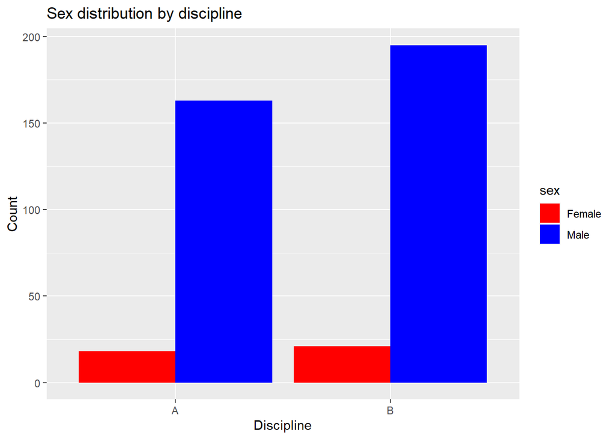

```r
p3 <- ggplot(data=Salaries, aes(x=discipline, fill=sex))+
      geom_bar(stat="count", position="dodge") + #add position="dodge" to geom_bar to have the groups next to each other
      labs(x = "Discipline", y = "Count")+
      ggtitle("Sex distribution by discipline") +
      scale_fill_manual(values=c("red", "blue"))

p3
```

Comments:

## Editing theme and scale

In this section, we will change theme, legend and scale of each of the plots above to find aesthetically attractive and informative plots.

For this purpose I will create a custom theme and a custom legend guide, which will be used for the above plots.

```r
theme_mine <- function(){
    theme(
          plot.title = element_text(color = "#213035", size = 15, face = 'plain', hjust = 0.5),
          axis.line = element_line(linetype = "solid",size = 1),
          axis.ticks = element_blank(), # no ticks
          axis.text = element_text(colour = "#595959",size = 9),

          # background settings
          panel.grid.major = element_line(linetype = "solid",
                                          colour = "#595959",
                                          size = 0.5
                                           ),
          panel.grid.minor = element_line(linetype = "solid",
                                          colour = "#595959",
                                          size = 0.2
                                           ),
          panel.background = element_rect(fill = "#ffffcf", colour = "#551155", size = 1), #panel background
          plot.background = element_rect(colour = "#151414", size = 1), # plot background

          strip.background = element_rect(fill = NA),
          strip.text = element_text(colour = "#595959",size = 9),

            legend.key = element_rect(fill = '#ffffcf') # legend rectangle same color as the panel

      )
      }
```

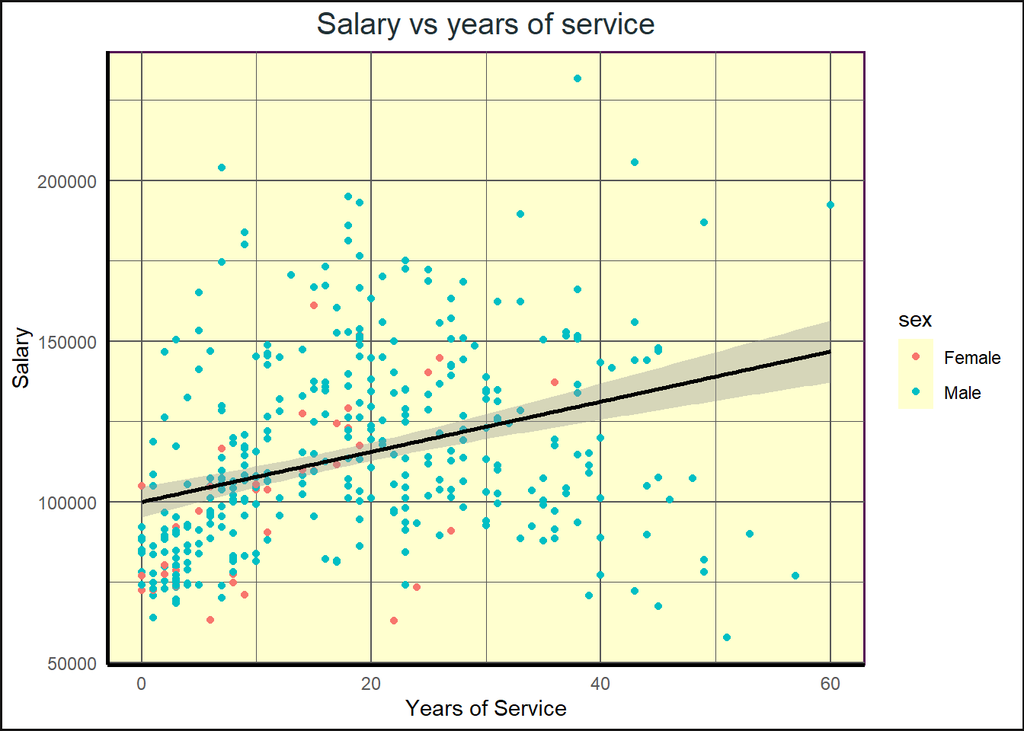

```r
p1 + theme_mine()
```

Custom guide for legend

```r
guide_mine <- function(){
    guides(color =  guide_legend(title.position = "top",
                                  title.hjust = 0.5,
                  label.theme = element_text(size = 10,colour = "black",
                                             angle = 0),
                                     label.position = "right"),  #position relative to the label icon
                  # ncol = 1,
                  # reverse = FALSE,
                  keyheight = 3, # the height of a rectangle
          keywidth = 3,

          # byrow = TRUE,
          # override.aes = list(shape = 15, alpha = 1, size = 8),
          title.theme = element_text(size = 15, # font size
                                     face = "bold", # font sub-type (bold)
                                     colour = "blue", # font color
                                     angle = 90 )) # rotate font box

}
```

Plots, ‘p1’ and ‘p2_1’ have better aesthetics with the theme and guide defined above

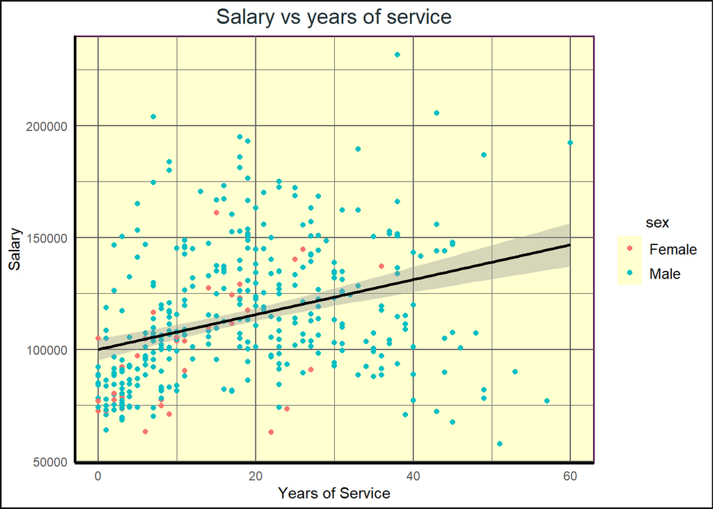

```r
p1 + theme_mine() + guide_mine()
```

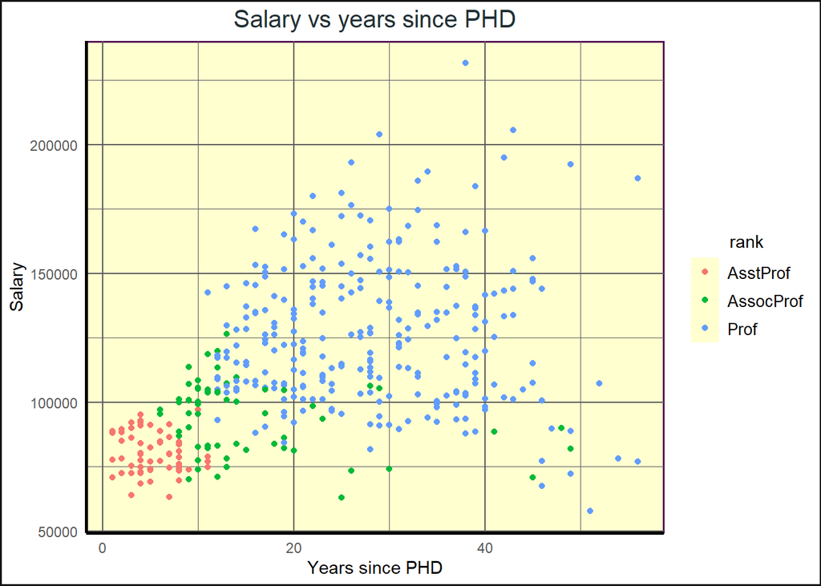

```r
p2_1 + theme_mine() + guide_mine()
```

### Editing Scales

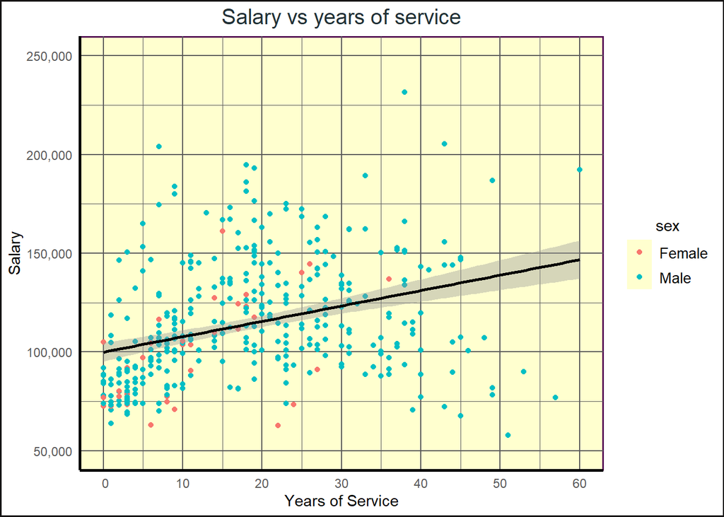

```r
p1 + theme_mine() + guide_mine() +
  scale_y_continuous(breaks = seq(0, 250000, by = 50000),
                     labels = format(seq(0, 250000, by = 50000), big.mark = ","),
                     limits = c(50000, 250000),
                 ) +
  scale_x_continuous(breaks = seq(0, 60,10),
                     labels = format(seq(0, 60,10)),
                     limits = c(0, 60),
                 )
```

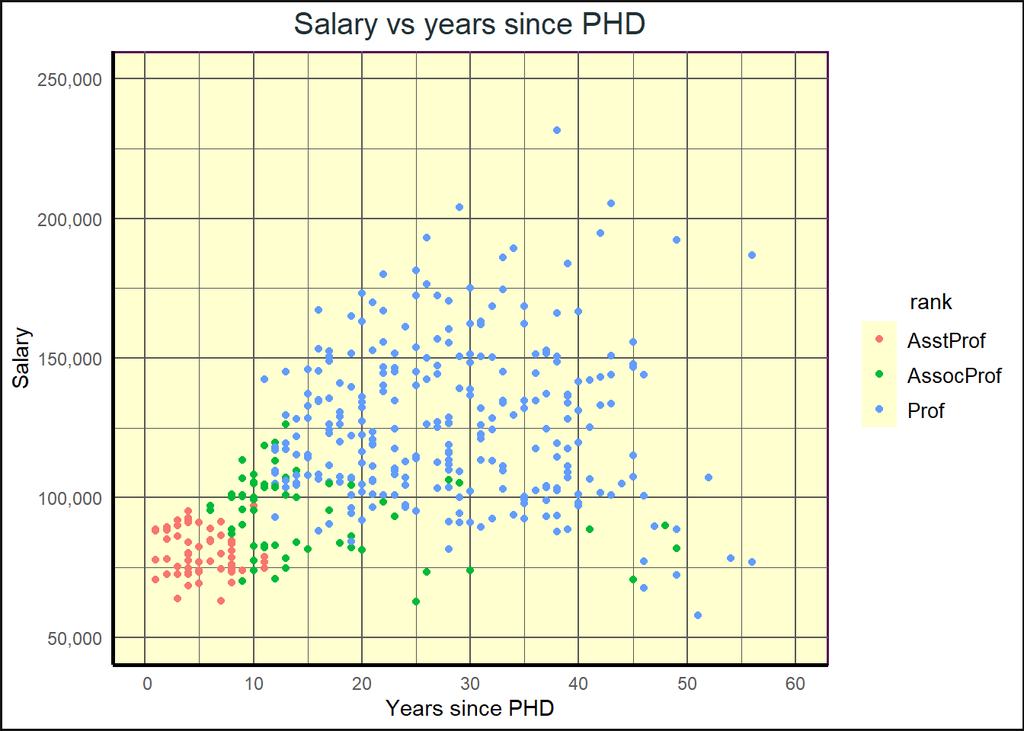

```r
p2_1 + theme_mine() + guide_mine() +
  scale_y_continuous(breaks = seq(0, 250000, by = 50000),
                     labels = format(seq(0, 250000, by = 50000), big.mark = ","),
                     limits = c(50000, 250000),
                 ) +
  scale_x_continuous(breaks = seq(0, 60,10),
                     labels = format(seq(0, 60,10)),
                     limits = c(0, 60),
                 )
```

*Editing plot 3*

*p3* is a bar plot. Let’s give it a different theme than defined above.

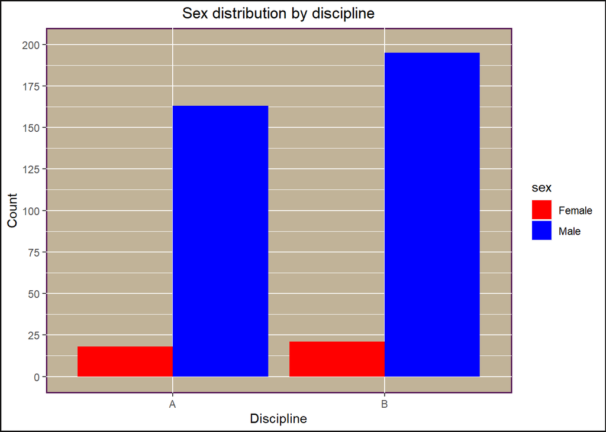

```r
p3 +
  theme(plot.title = element_text(hjust = 0.5),# title to the middle
        panel.background =  # panel background color and size
            element_rect(fill = "#c1b398", colour = "#551155", size = 1),
        plot.background =  # plot background color and size
            element_rect(colour = "#151414", size = 1)) +

  # rescale the y - axis for better resolution
  scale_y_continuous(breaks = seq(0, 200, by = 25),
                     labels = seq(0, 200, by = 25),
                     limits = c(0, 200),
                 )
```